# DSE 511 Final Project Cluster Analysis in R

Cecilia Albert-Black

2025-11-11

Set working directory to R code folder

```r
setwd("C:/Users/q4q/repos/DSE511_Final_Project/Step 3. Cluster Analysis/R Code")
```

Load necessary libraries

```r
library(readr)
library(tidyverse)
library(fitdistrplus)
```

Import dataset from Step 1. Data Cleaning

```r
clean_df <- read_csv("C:/Users/q4q/repos/DSE511_Final_Project/Step 1. Data Cleaning/R code/outbreak_clean_r_v2.csv")
head(clean_df)
```

```
## # A tibble: 6 × 30
##    Year Month Date    Season State      State_abbr Primary_mode Setting Etiology
##   <dbl> <dbl> <chr>   <chr>  <chr>      <chr>      <chr>        <chr>   <chr>
## 1  1971     2 1971-02 Winter California CA         Water        Restau… Copper
## 2  1971     6 1971-06 Summer Arkansas   AR         Water        Store   Hepatit…
## 3  1971     6 1971-06 Summer Missouri   MO         Water        Subdiv… Unknown
## 4  1971     6 1971-06 Summer Alabama    AL         Water        Unknown Selenium
## 5  1971     6 1971-06 Summer Vermont    VT         Water        Commun… Unknown
## 6  1971     6 1971-06 Summer Oregon     OR         Water        Restau… Unknown
## # ℹ 21 more variables: Etiology_group <chr>, IFSAC_category <chr>,
## #   Food_vehicle <chr>, Water_exposure <chr>, Water_type <chr>,
## #   Water_type_group <chr>, Animal_type <chr>, Animal_type_group <chr>,
## #   Illnesses <dbl>, Hospitalizations <dbl>, Deaths <dbl>,
## #   Hospitalizations_std <dbl>, Deaths_std <dbl>, Illnesses_std <dbl>,
## #   Hosp_per_ill <dbl>, Death_per_ill <dbl>, Food_vehicle_missing <chr>,
## #   Water_exposure_missing <chr>, is_food_related <dbl>, …
```

## Distribution Function of Numeric Variables

Before conducting a cluster analysis, we first need to determine the distribution function of the numeric variables which will be used in the cluster analysis. This will govern what type of cluster analysis we will perform.

From Step. 2 Exploratory Data Analysis in R, we observed the numeric variables and their log-transformations were not normally distributed. Thus, we will explore other distribution functions to fit the numeric variables.

### I. Poisson Distribution for Count Data

Poisson distribution function is suitable for count data (non-negative integers with variance ≈ mean) because it uses a log-link function to account for the logarithmic distribution of variables. We will only be fitting a Poisson to Illnesses, Hospitalizations, and Deaths (not ratios).

The Poisson distribution function is defined by one parameter called lambda,as shown below:

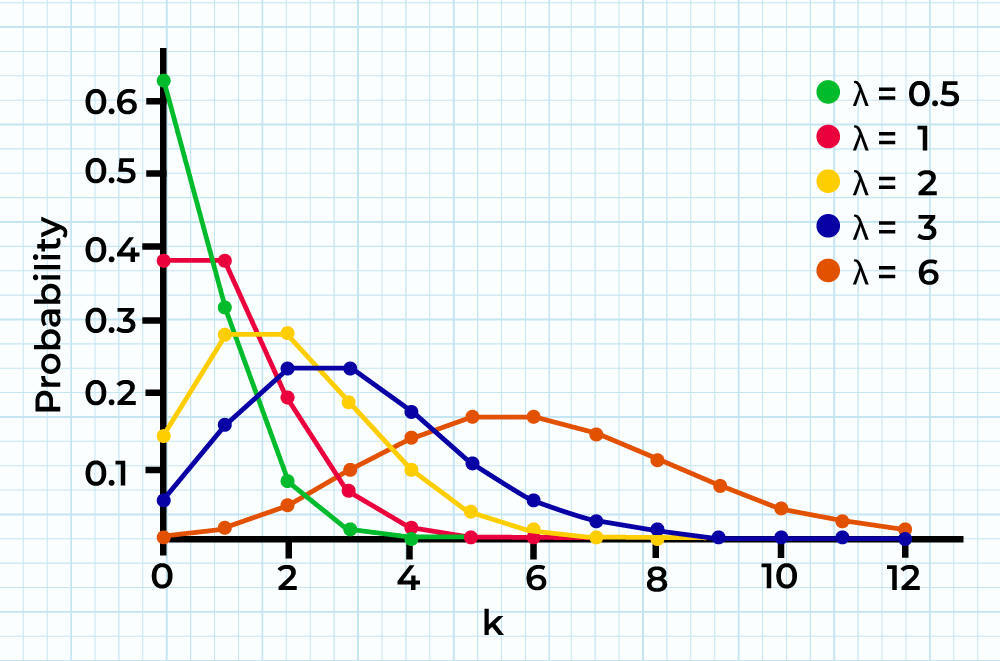

Visualize the fitted Poisson distributions

```r
# Fit poisson distribution to variables
ill_pois <- fitdistr(clean_df$Illnesses, "poisson")
hosp_pois <- fitdistr(clean_df$Hospitalizations, "poisson")
death_pois <- fitdistr(clean_df$Deaths, "poisson")

# Extract lambdas
ill_lambda <- ill_pois$estimate["lambda"]
hosp_lambda <- hosp_pois$estimate["lambda"]
death_lambda <- death_pois$estimate["lambda"]

# View
ill_lambda
```

```
##   lambda
## 33.25166
```

```r
hosp_lambda
```

```
##    lambda
## 0.7196049
```

```r
death_lambda
```

```
##     lambda
## 0.03733905
```

Plot the fitted Poisson distribution to the histogram of each count variable